Lexi Eid and Krithi Choudhary  
Dr. Ozak  
ECON 4362  
25 September 2022

# Empirical Topic and Idea

## Potential Title

### Paying for Poverty: Why Resource Endowment Prevents Growth

## Question/ Problem We’re Addressing

Beginning in the 1950s, scholars have reflected on the lack of development in low and middle-income countries. This correlation between lower income and slower growth was originally suspected to be a factor of path dependence, where a lack of wealth in the 1800s and 1900s could lead to a lack of growth in the 21st century. However, the 1980s demonstrated that lower-income countries CAN experience rapid economic growth, by a factor of more than 10% per year. In particular, the “miracle growth” countries like China, Korea, and Japan, categorized as countries with sustained economic growth of more than 6% per year, inspired further research. Still, the majority of low-income nations remained low-income. Some glaring exceptions also stood out: countries endowed with natural resources which should catalyze growth and integration into the international economy. Often, the results were counterintuitive to logic. These countries, endowed with oil, natural gas, and other high-value-added resources, experienced slower economic growth than their high-income counterparts and their low-income neighbors. In 1993, Richard Auty coined the term *resource curse* to describe this phenomenon of lower economic growth in resource-abundant countries.

The resource curse was inspired by another similar phenomenon, the Dutch disease. The Dutch disease suggests that increased exports of natural resources instigated a decline in national production competitiveness and created conditions for recessions. Growing natural resource markets often correlate to weakened export markets of goods and services because tradable goods become less competitive as the country becomes less specialized in its non-resource goods. Particularly for countries in the fuel industry, these changes in specialization influence how competitive countries are in the international and create unfavorable conditions for economic growth. The resource curse expands this phenomenon to include economic stagnation and stunting of growth in sectors outside of the export market.

Our research aims to investigate this exact topic: *How does the resource curse affect low-income economies and do natural resources induce economic stagnation?*

Some potential factors that subdue growth in resource-heavy economies are:

1. Volatility of prices  
   Most natural resources are roughly price inelastic on the supply and demand side, making the market highly vulnerable to small price changes. Changes in demand or supply shocks of all kinds can create large swings in prices that affect the market rapidly. As Michael Ross highlights, “the price of oil is more volatile than the price of 95 percent of all products sold in the United States,” making energy resources and other natural resources dangerous investments (Ross, 50). When governments rely on these revenues, economic growth is highly dependent on international prices. If prices dip, as they did in 2020 during the COVID pandemic, unexpected changes can create detrimental setbacks in growth. Goods and services are much less volatile, making them safer investments for growth. Resource-rich countries are therefore at the mercy of the international market for economic revenue and growth.
2. Resource Rent Revenues in the government  
   Overwhelmingly, a positive correlation exists between resource endowment and the size of government. These larger governments are also disproportionately dependent on revenues from natural resources, relying less on taxes than their resource-poor counterparts (Ross, 29). These disproportionately large governments rely on resource revenues and often fail to stabilize their economies due to shorter time horizons. The alternating periods of high prices tend to correlate with faster growth whereas low prices are associated with poor budgeting and high expenditures. Thus, a look into the governmental rents from resources can reveal where money is wasted or spent on consumption rather than investment.
3. Income Stagnation and Unemployment  
   As a factor of the Dutch disease, a competitive advantage in natural resources prevents development in other export industries. The “competitive hypothesis” of the resource curse argues that specialization in the resource industry can subdue growth in more diversified and stable industries, thus preventing the overall growth of the economy (Mershed and Serino, 152). In addition, the overemphasis on the resource sector can create unemployment as jobs shift from other industries. In the long term, the oversaturation of the labor market can create wage stagnation, lower GDP per capita, and lower standards of living. This combination of hyperspecialized industries and low wages can subdue economic growth, even when prices for natural resources are high.

## Relevance

In 2012, the International Monetary Fund (IMF) categorized 51 nations as “resource-rich,” which account for a population of more than a billion people. A majority of these nations showed exhaustible natural resources account for at least 20% of fiscal revenue or 20% of exports. 29 of these nations have incomes that are low or lower middle class (Venables, 16). The 29 nations share the following traits: heavy reliance on natural resource wealth for taxation, exports, or both, inadequate savings rates, subpar economic performance, and highly variable resource income.

Resources account for one of the world’s largest sectors, accounting for nearly 20% of global production. The growing influence of oil and natural gas in recent decades also increased the influence of the resources market. However, with the growing influence of green energies and increased awareness of the dangers of mineral mining, there are increasing pressures to limit the natural resource industries. Moving into the future, shifts towards renewable energy sources could threaten the already rocky stability of resource markets. Understanding the potential influences in these markets can improve their transition into new markets and avoid the negative consequences of market shifts.

## Plan to Answer

Our research will compare overall GDP growth and GDP per capita growth over time between resource-endowed countries and their resource-poor counterparts. Our hypothesis to be tested is that *resource endowment is correlated to economic stagnation, slower economic growth, and subdued growth in GDP per capita.*

We will also be comparing the price of natural resources over time to demonstrate how market prices can influence GDP in resource-endowed countries more than their counterparts. Often, research on this topic looks specifically at the influence of resource exports on GDP. However, we plan to use a model similar to Michael Ross’ which compares the total domestic and exported production of natural resources against GDP per capita to capture a more comprehensive view of the influence of resource markets (Ross, 16-17). Thus, trends indicating a strong correlation between weak economic growth and resource endowment will support our thesis.

## Data

The data necessary to assess our argument is compiled into five essential pieces of data:

1. Statistics of resource endowment, detailing which resource each country has and the percent of GDP \
2. GDP growth (and reductions) since exporting natural resources \
3. GDP per capita growth (and reductions) since exporting natural resources \
4. Prices of the natural resources since exportation began \

and  
5) Government rents from natural resources and their factor of total GDP/production.

These five factors will demonstrate how the exchange of natural resources has changed in recent years and how developing economies have responded. As outlined above, our goal is to compare the data on the total production of natural resources to GDP per capita and total GDP growth to measure whether correlations exist between the two variables. The prices of the resources and the government rents will serve as control variables, to test whether extreme variation in GDP comes from internal or external factors. Due to a large number of confounding variables, we chose two external factors (price and government rents) to measure internal and external pressure on the market at all times.

## DAG

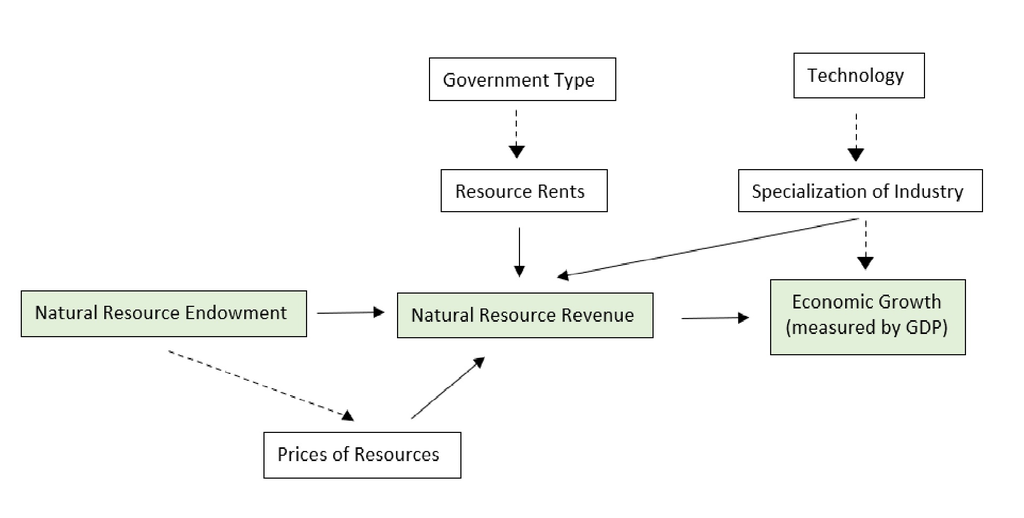

## Format

The structure of our presentation is modeled around a economic magazine article. The format will resemble a news story similar to *The Economist* or the Econometric Society's publication, *Econometrica*. We will combine data generated in econometrica.com, such as statistics and regression analyses to combine our data and analytical analysis. Our presentation will be semi-formal, using professional language but more layman's terms. Ideally, our audience would be educated readers who are not necessarily familiar with economic jargon.

Below is an example of a cover page we hope to emulate. The presentation should be both engaging and informative.

[figure not shown]

## Timeline

September 25: Choose a topic and explain the idea  
- Finish Step 1  
Early October: Define the scope of the project and solidify variables  
- Choose countries for data collection  
Late October: Collect data and create a hypothesis  
October 23: Complete data analysis and empirical explanation of the data  
- Finish Step 2  
Early November: finalize the argument and create concluding remarks  
November 28: Finalize project and complete presentation  
- Finish Step 3

## Sources

Adams, Dawda, Kweku Adams, Subhan Ullah, and Farid Ullah. “Globalisation, Governance, Accountability and the Natural Resource ‘curse’: Implications for Socio-Economic Growth of Oil-Rich Developing Countries.” *Resources Policy* 61 (2019): 128–40. https://doi.org/10.1016/j.resourpol.2019.02.009.

Ghura, Dhaneshwar and Catherine Pattillo. “Macroeconomic Policy Frameworks for Resource-Rich Developing Countries.” *International Monetary Fund* (2012): 1-55.

Haseeb, Muhammad, Sebastian Kot, Hafezali Iqbal Hussain, and Fakarudin Kamarudin. “The Natural Resources Curse-Economic Growth Hypotheses: Quantile–on–Quantile Evidence from Top Asian Economies.” *Journal of Cleaner Production* 279 (2021): 123596–. https://doi.org/10.1016/j.jclepro.2020.123596.

Lederman, Daniel, William F. Maloney. *Natural Resources Neither Curse nor Destiny.* Palo Alto, CA: Stanford Economics and Finance, an imprint of Stanford University Press, 2007.

Murshed, Syed Mansoob, and Leandro Antonio Serino. “The Pattern of Specialization and Economic Growth: The Resource Curse Hypothesis Revisited.” *Structural Change and Economic Dynamics* 22, no. 2 (2011): 151–61. https://doi.org/10.1016/j.strueco.2010.12.004.

Ross, Michael Lewin. *The Oil Curse : How Petroleum Wealth Shapes the Development of Nations.* Princeton, N.J: Princeton University Press, 2012.

Shu Yang, Elyas Abdulahi, Muhammad Afaq Haider, and Muhammed Asif Khan. “Revisiting the Curse: Resource Rent and Economic Growth of Sub-Sahara African Countries.” *International Journal of Economics and Financial Issues* 9, no. 1 (2019): 121–30.

Venables, Anthony. “Using Natural Resources for Development: Why Has It Proven So Difficult?” *Journal of Economic Perspectives*, 30 no.1 (2016): 161-184. https://www.aeaweb.org/articles?id=10.1257/jep.30.1.161.

Wang, Rong, Junlan Tan, and Shuangliang Yao. “Are Natural Resources a Blessing or a Curse for Economic Development? The Importance of Energy Innovations.” *Resources Policy* 72 (2021): 102042–. https://doi.org/10.1016/j.resourpol.2021.102042.

Williams, Andrew. “Shining a Light on the Resource Curse: An Empirical Analysis of the Relationship Between Natural Resources, Transparency, and Economic Growth.” *World Development* 39, no. 4 (2011): 490–505. https://doi.org/10.1016/j.worlddev.2010.08.015.

## Sample of Data Sources:

[Venables - Appendix Data](https://assets.aeaweb.org/asset-server/articles-attachments/jep/app/3001/30010161_app.pdf)  
[World Bank - GDP growth Data](https://data.worldbank.org/indicator/NY.GDP.MKTP.KD.ZG)  
[World Bank - GDP per capita Data](https://data.worldbank.org/indicator/NY.GDP.PCAP.KD.ZG)  
[World Bank - Oil Rents as % of GDP](https://data.worldbank.org/indicator/NY.GDP.PETR.RT.ZS)  
[World Bank - Total Exports as % of GDP](https://data.worldbank.org/indicator/NE.EXP.GNFS.ZS)